# PCA and kernel PCA analysis

PCA and kernel PCA analysis Analysis of dependancy of ctitical temterature of superconductors. Valeriia Ladyhina 2021-12-08

**In this project we performed PCA analysis of superconductors.**

Now the script will automatically download and install all required R libraries. Please wait a bit.

**Step 1: Download needed data**

Now we will check if all needed for the analysis already exist in the folder ‘Data’, if no it will be downloaded and unpacked.

```r
if (file.exists('./Data')) {
output_answer<-"1. 'Data' folder exists."
} else {
 output_answer<- "1. For futher work 'Data' folder will be created in the working directory."
 dir.create('./Data')
}
```

1. ‘Data’ folder exists.

```r
if (file.exists('./Data/superconduct.zip')) {
 output_answer<- '2. Zip file was already downloaded.'
} else {
 output_answer<- "2. Zip file needed for analysis will be dowloaded into 'Data' folder."
 download.file('https://archive.ics.uci.edu/ml/machine-learning-databases/00464/superconduct.zip','./Data/superconduct.zip')
}
```

2. Zip file needed for analysis will be dowloaded into ‘Data’ folder.

**Step 2: Unzip file**

```r
if (file.exists('./Data/train.csv') & file.exists('./Data/unique_m.csv')) {
 output_answer<- '3. Files that are needed for analysis already exist.'
} else {
 output_answer<- "3. Downloaded zip file will be unpacked in the folder 'Data'."
 unzip('./Data/superconduct.zip',exdir = './Data')
}
```

3. Downloaded zip file will be unpacked in the folder ‘Data’.

**Step 3: Combining data**

```r
file1<- read.csv('./Data/train.csv')
file2<- read.csv('./Data/unique_m.csv')
file2<- dplyr::select(file2,-material)
data<-cbind(file1,file2)
```

**Step 4: Division of data on test and training sets**

```r
train_size<-sample(seq_len(nrow(data)), size = floor(0.75 * nrow(data)))
train_data <- data[train_size, ]
test_data <- data[-train_size, ]
```

**Step 5: Data standatisation**

```r
normParam <- preProcess(train_data)
# There are few elements that have zero variance: He, Ne, Ar, Kr, Xe, Pm, Po, At, Rn.
norm.train_data <- predict(normParam, train_data)
norm.test_data <- predict(normParam, test_data)
norm.train_data<-dplyr::select(norm.train_data,-c(1,82))
norm.train_data<-dplyr::select(norm.train_data,-c(He, Ne, Ar, Kr, Xe, Pm, Po, At, Rn))
norm.test_data<-dplyr::select(norm.test_data,-c(1, 82))
norm.test_data<-dplyr::select(norm.test_data,-c(He, Ne, Ar, Kr, Xe, Pm, Po, At, Rn))
```

**Step 6: Linear model that predicts critical temperature based on all existing charecteristics**

```r
model <- lm(critical_temp ~ ., data = norm.train_data)
model_summary <- summary(model)
```

**Step 7: Train PCA model**

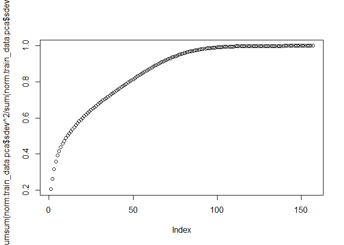

```r
norm.train_data.pca<-prcomp(norm.train_data[,-158])
plot(cumsum(norm.train_data.pca$sdev^2/sum(norm.train_data.pca$sdev^2)))
```

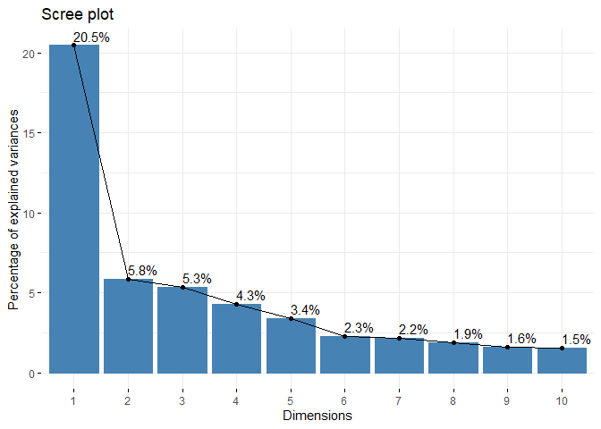

```r
fviz_screeplot(norm.train_data.pca, addlabels = TRUE)
```

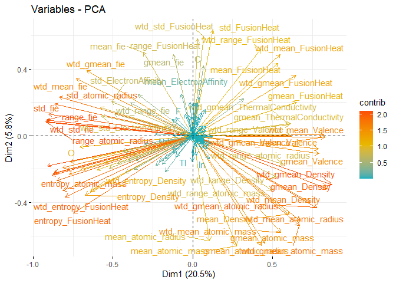

```r
var <- get_pca_var(norm.train_data.pca)
fviz_pca_var(norm.train_data.pca, col.var="contrib",
             gradient.cols = c("#00AFBB", "#E7B800", "#FC4E07"),
             repel = TRUE )
```

```r
coef7<-as.data.frame(norm.train_data.pca$x[,1:7])
coef70<-as.data.frame(norm.train_data.pca$x[,1:70])
mult_coefs <- function(row, coef) sum(row * coef)
norm.test_data.pca7 <- as.data.frame(sapply(colnames(coef7), function(name) apply(norm.test_data, 1, function(row) mult_coefs(row, coef7[name]))))
norm.test_data.pca7$critical_temp <- test_data$critical_temp
model7 <- lm(critical_temp ~ ., data = norm.test_data.pca7)
model7_summary <- summary(model7)
#norm.test_data.pca70 <- as.data.frame(sapply(colnames(coef70), function(name) apply(norm.test_data, 1, function(row) mult_coefs(row, coef70[name]))))
#norm.test_data.pca70$critical_temp <- test_data$critical_temp
#model70 <- lm(critical_temp ~ ., data = norm.test_data.pca70)
#model70_summary <- summary(model70)
```

```r
norm.test_data.pca <- predict(norm.train_data.pca, norm.test_data)
pc <- c(1,2)
png("pca_pred.png", units="in", width=5, height=4, res=200)
plot((norm.train_data.pca$x[,pc]))
 points(norm.test_data.pca[,pc],col = 'red')
 legend("topleft", legend=c("training data - black", "validation data - red"))
```

**Step 8: Kernel PCA model** As it was taken too much memory I reduced size of the data sets to 3000 measurements. I know - it is no representative results, but wanted to try to do it in R and it still didn’t work…:(.

```r
#kpca <-  kPCA(norm.train_data[1:3000,], kernel = 'rbfdot')
#norm.test_data.kpca <-  as.data.frame(predict(kpca, norm.test_data[1:3000,]))
#norm.test_data.kpca$critical_temp <- test_data$critical_temp[1:3000]
#kpca_model<-lm(critical_temp ~ ., data = norm.test_data.kpca)
#modelkpca <- lm(critical_temp ~ ., data = norm.test.kpca)
#modelkpca_summary <- summary(modelkpca)
```